← Back to the hackathon home

Topic 11 of 18

# DHIS2 Indicators

Step-by-Step Guide: Creating, Configuring and Testing Indicators

**Purpose of this guide:** This guide explains how to create an indicator in DHIS2 from the underlying data elements through testing and visualization. After each step, insert a screenshot from your own DHIS2 instance in the marked area.

Step 1: Understand What an Indicator Is

An indicator in DHIS2 is a calculated value derived from one or more data elements. Indicators are commonly used for rates, percentages, ratios and coverage measures.

```
INDICATOR
   │
   ├── Numerator
   │       ↓
   │   Data Element
   │
   ├── Denominator
   │       ↓
   │   Data Element
   │
   └── Factor
           ↓
        × 100
```

### Example

**Indicator:** Malaria Testing Rate (%)  
**Numerator:** Number of malaria tests performed  
**Denominator:** Number of suspected malaria cases  
**Factor:** 100

**Expected result:** You understand the numerator, denominator and factor required before creating the indicator.

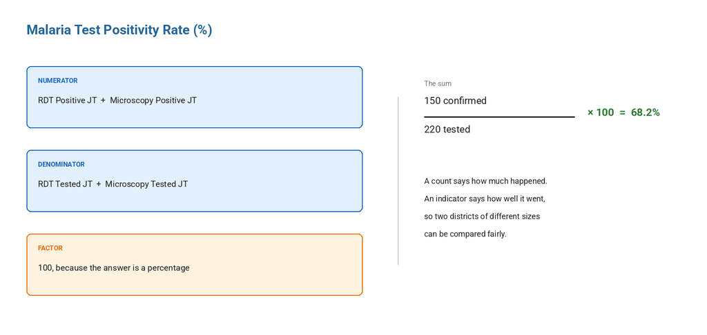

123456

**Figure 1.** The three parts of the indicator, with the numbers worked through. *This picture was drawn for the guide, using the indicator we are building. Your screen will show your own names and dates.*

1. 1**Numerator.** The confirmed cases, the top of the fraction.
2. 2**Denominator.** The people tested, the bottom of the fraction.
3. 3**Factor.** 100, which turns 0.682 into 68.2 per cent.
4. 4**150 confirmed.** What the numerator adds up to in one facility and month.
5. 5**220 tested.** What the denominator adds up to for the same facility and month.
6. 6**68.2%.** The answer DHIS2 should give. Keep this number to check with in Step 16.

Step 2: Check the Data Elements First

Before creating an indicator, confirm that the data elements needed for the calculation already exist.

**Click:** Maintenance / Metadata Management → Data Elements

### For the malaria testing example, check for:

- Malaria Suspected Cases
- Malaria Tests Performed

If the required data element does not exist, create it before proceeding with the indicator.

**Expected result:** Both numerator and denominator data elements are available.

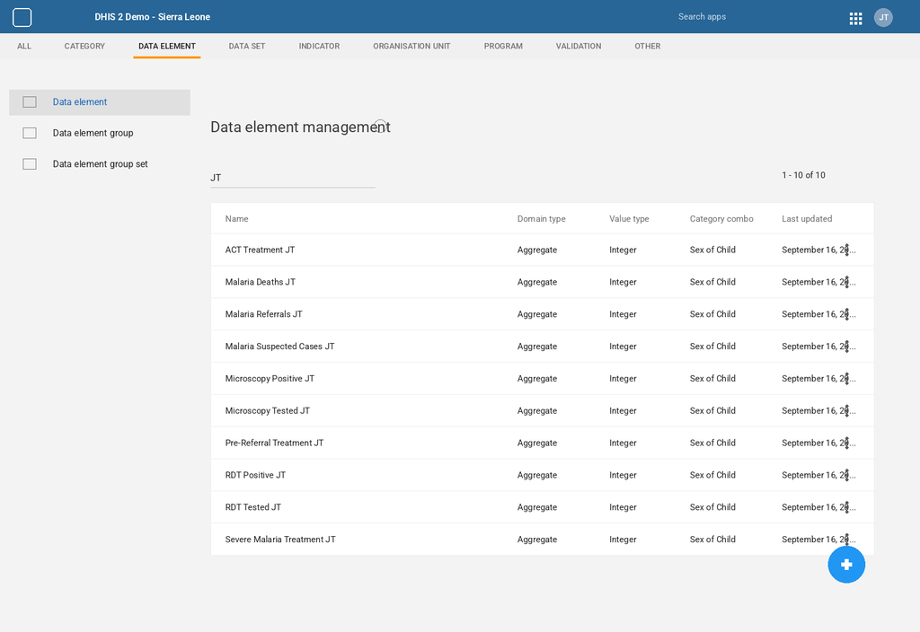

1234567

**Figure 2.** Your ten malaria data elements, found by searching your initials. *This picture was drawn for the guide, using the indicator we are building. Your screen will show your own names and dates.*

1. 1**Data element.** The side menu item you are in.
2. 2**Data element management.** The list of everything that can be counted.
3. 3**Search.** Your initials, so only your ten appear.
4. 4**Count.** 1 to 10 of 10, which is what you created in Topic 1.
5. 5**The names.** These are the names you will pick inside the expression builder.
6. 6**Value type.** Integer, so the sums in the indicator work.
7. 7**Category combination.** Sex of Child, so the indicator adds both columns together.

Step 3: Open Indicators

Open the Indicators section in the DHIS2 Maintenance/Metadata Management application.

**Click:** Maintenance app → INDICATOR tab → Indicator → list button

Search the list before creating anything. The demo already holds 77 indicators, and one of them may be close enough to copy.

**Expected result:** The Indicators list is displayed.

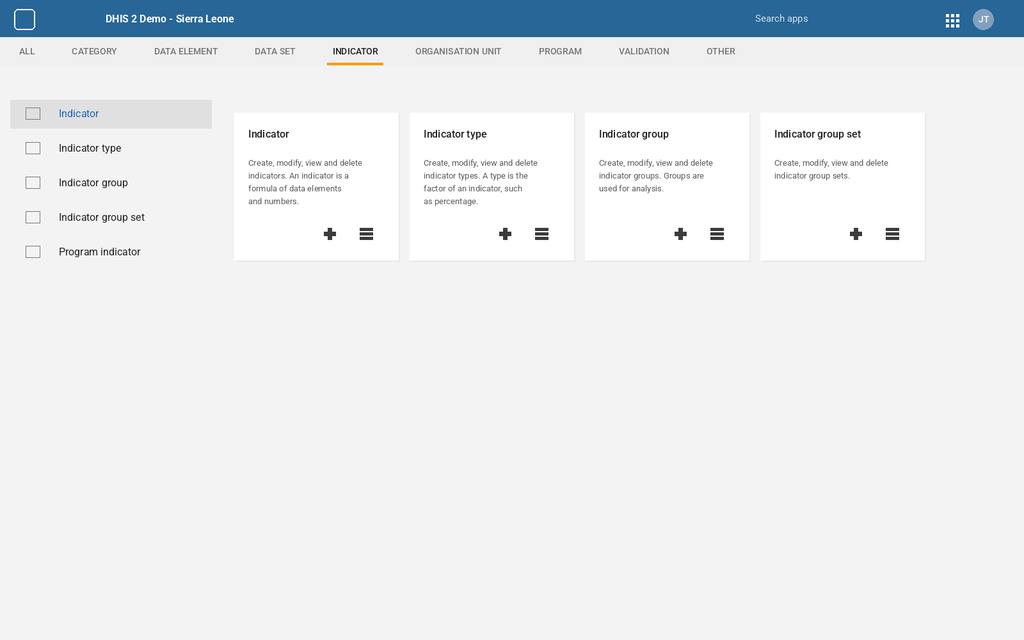

1234567

**Figure 3.** The INDICATOR tab, with the Indicator card and the Indicator type card. *This picture was drawn for the guide, using the indicator we are building. Your screen will show your own names and dates.*

1. 1**INDICATOR tab.** The orange line shows the tab you are on.
2. 2**Side menu.** The same items as the cards, for quick jumping.
3. 3**Indicator.** Where the indicator itself is created.
4. 4**Plus.** Starts a new indicator.
5. 5**List.** Shows the indicators that already exist. Always look here first.
6. 6**Indicator type.** Where the factor lives, used in Step 4.
7. 7**Indicator group.** For grouping indicators once you have several.

Step 4: Create an Indicator Type

Some DHIS2 versions use Indicator Types to define how an indicator is expressed, particularly the factor used for percentage or rate indicators.

**Click:** INDICATOR tab → Indicator type → list, and only use the blue plus if the type you need is missing

**Example indicator type:**  
Name: Percentage  
Factor: 100

For a percentage indicator, the factor is normally `100`.

**Expected result:** A Percentage indicator type is available for selection when creating indicators.

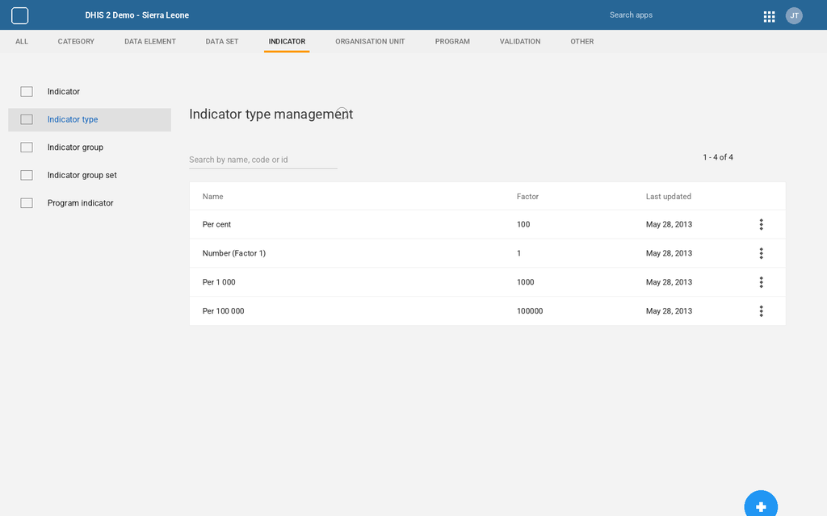

123456

**Figure 4.** The indicator types that already exist, with their factors. *This picture was drawn for the guide, using the indicator we are building. Your screen will show your own names and dates.*

1. 1**Indicator type.** The side menu item.
2. 2**Indicator type management.** The list of types.
3. 3**Factor column.** What each type multiplies by.
4. 4**Per cent, 100.** Use this for positivity, coverage and completeness.
5. 5**Number, factor 1.** Use this for a plain count, with a denominator of 1.
6. 6**Blue plus.** Only use it when the factor you need is genuinely missing.

Step 5: Start Creating the Indicator

Return to Indicators and start a new indicator.

**Click:** INDICATOR tab → Indicator card → blue plus button

The indicator creation form should open.

**Expected result:** You see the fields needed to define the indicator.

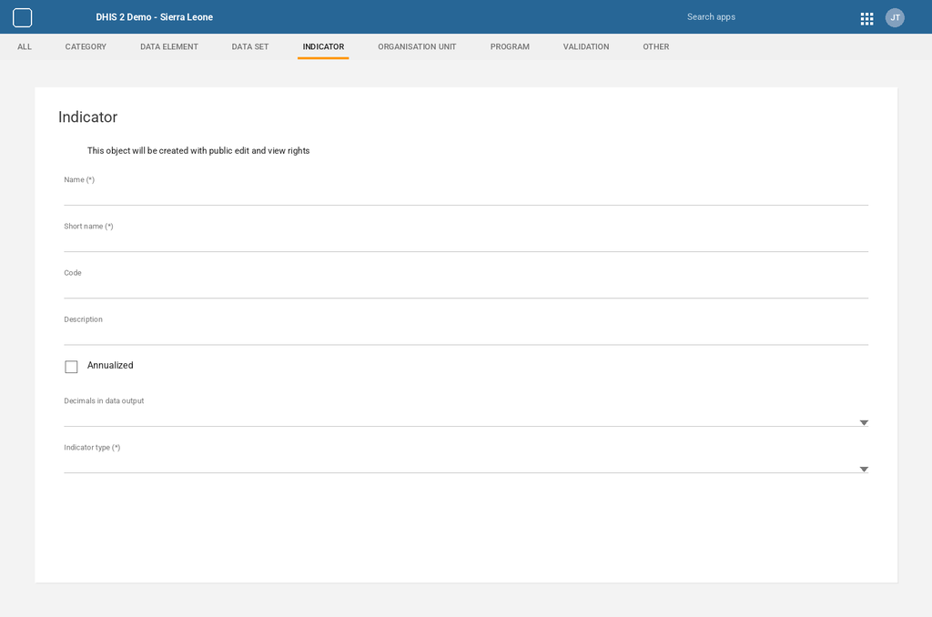

123456789

**Figure 5.** The empty indicator form. *This picture was drawn for the guide, using the indicator we are building. Your screen will show your own names and dates.*

1. 1**INDICATOR tab.** The form opens on the same tab.
2. 2**Sharing note.** The indicator will be public until you change it in Step 14.
3. 3**Name (*).** Required.
4. 4**Short name (*).** Required, and it must be unique.
5. 5**Code.** Optional.
6. 6**Description.** Optional, but write it anyway.
7. 7**Annualized.** Off for a monthly rate.
8. 8**Decimals in data output.** How many decimals people will see.
9. 9**Indicator type (*).** Required. This is the factor, set in Step 7.

Step 6: Enter the Indicator Name

Give the indicator a clear and meaningful name.

**Example:**  
Name: Malaria Testing Rate (%)  
Short Name: Malaria Testing Rate  
Code: MAL_TEST_RATE

### Naming principle

The name should make it clear what is being measured and, where relevant, include the unit such as %, rate, ratio or coverage.

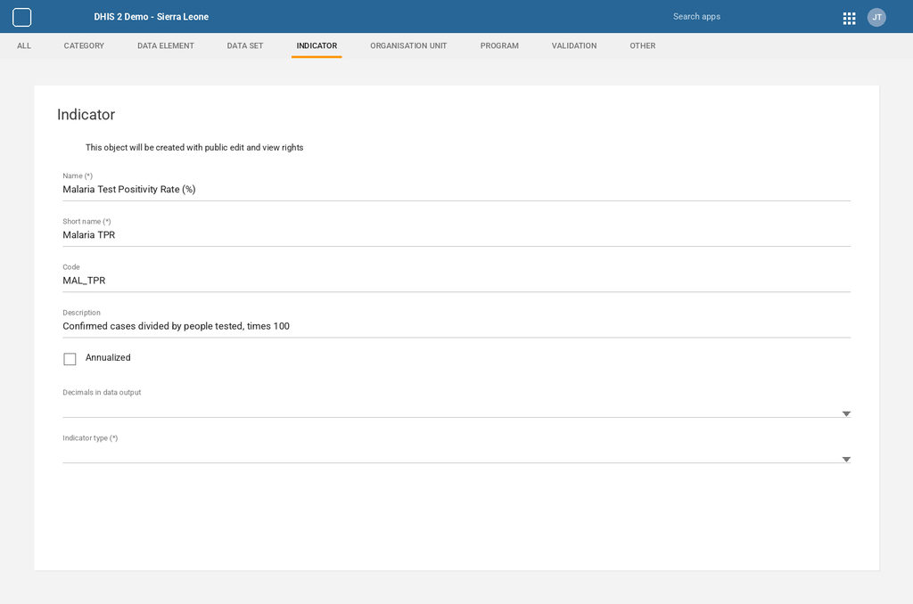

1234

**Figure 6.** Name, short name, code and description filled in. *This picture was drawn for the guide, using the indicator we are building. Your screen will show your own names and dates.*

1. 1**Name.** Malaria Test Positivity Rate (%). The unit is in the name, so nobody has to guess.
2. 2**Short name.** Malaria TPR, which is what charts and tables will show.
3. 3**Code.** MAL_TPR, useful when another system asks for this indicator.
4. 4**Description.** The formula in words: confirmed cases divided by people tested, times 100.

Step 7: Select the Indicator Type

Select the indicator type that corresponds to the calculation.

**Select:** Percentage

If you created a Percentage indicator type in Step 4, select it here.

**Expected result:** The indicator is configured as a percentage-type indicator.

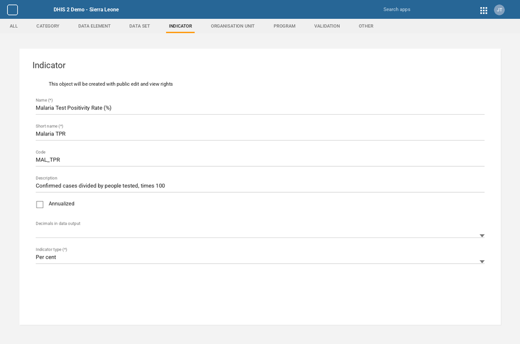

123

**Figure 7.** The indicator type set to Per cent. *This picture was drawn for the guide, using the indicator we are building. Your screen will show your own names and dates.*

1. 1**Indicator type.** Per cent, which carries the factor of 100.
2. 2**The arrow.** Opens the list of types from Step 4.
3. 3**Annualized.** Still off. Turning it on would multiply a monthly value up to a year.

Step 8: Build the Numerator

The numerator is the value that appears on top of the calculation.

**Malaria Testing Rate:**  
Numerator = Number of malaria tests performed

**Click:** Edit numerator → search the data element → click its name → check the preview and the green Valid → DONE

```
Numerator
    =
Malaria Tests Performed
```

**Expected result:** The numerator expression contains the correct data element.

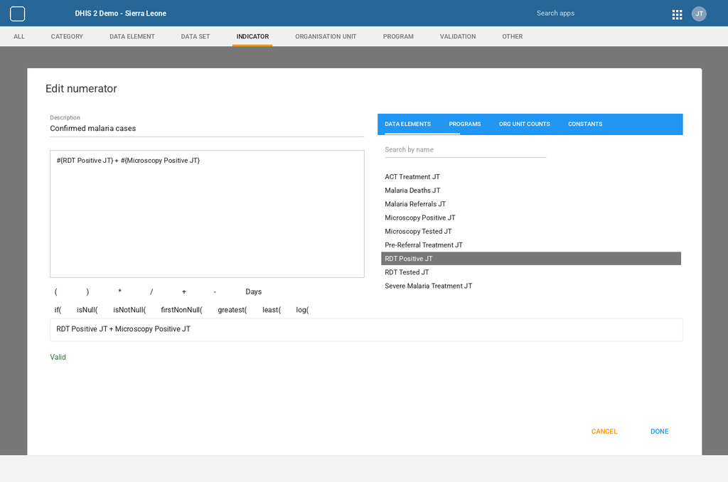

123456789

**Figure 8.** The numerator: two data elements added together. *This picture was drawn for the guide, using the indicator we are building. Your screen will show your own names and dates.*

Step 9: Build the Denominator

The denominator is the value below the calculation line.

**Malaria Testing Rate:**  
Denominator = Number of suspected malaria cases

**Click:** Edit denominator → build it the same way. For a plain count, type 1 as the whole expression

```
Denominator
    =
Malaria Suspected Cases
```

**Expected result:** The denominator expression contains the correct data element.

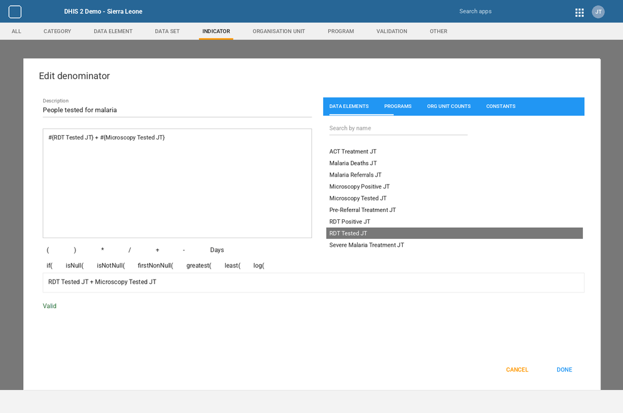

12345

**Figure 9.** The denominator: the two testing data elements. *This picture was drawn for the guide, using the indicator we are building. Your screen will show your own names and dates.*

1. 1**Description.** People tested for malaria.
2. 2**The expression.** RDT Tested plus Microscopy Tested, so every test counts once.
3. 3**Preview.** Check that the two elements here are the tests, not the positives.
4. 4**Valid.** Green again.
5. 5**DONE.** Keeps the denominator. For a plain count, the whole expression would be 1.

Step 10: Set the Factor

The factor converts the ratio into the desired unit.

| Indicator type | Typical factor |
| --- | --- |
| Proportion / percentage | 100 |
| Rate per 1,000 | 1,000 |
| Rate per 10,000 | 10,000 |
| Rate per 100,000 | 100,000 |

**Example:**  
(Malaria Tests Performed ÷ Malaria Suspected Cases) × 100

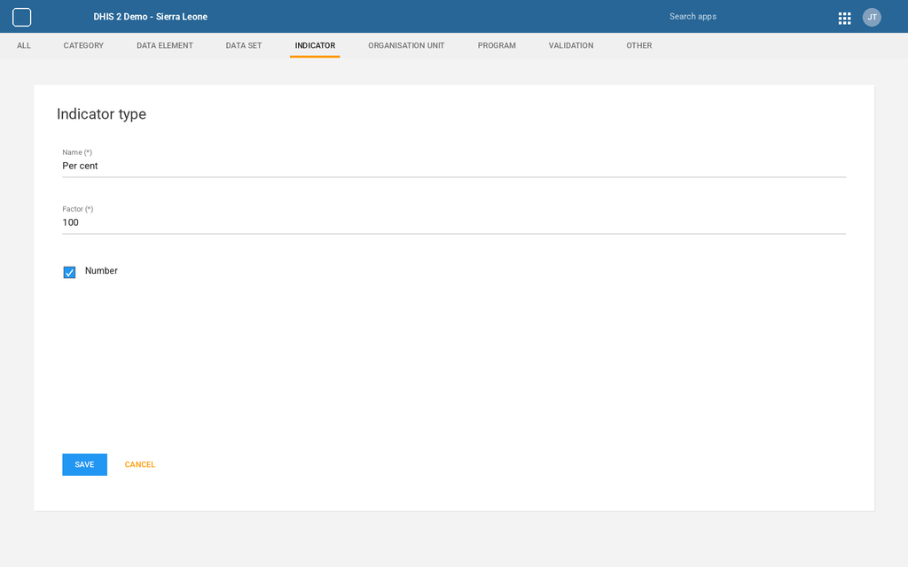

1234

**Figure 10.** The indicator type itself, where the factor of 100 lives. *This picture was drawn for the guide, using the indicator we are building. Your screen will show your own names and dates.*

1. 1**Name.** Per cent. Do not create a second type with the same meaning.
2. 2**Factor.** 100. The indicator value is numerator divided by denominator, times this.
3. 3**Number.** Ticked, because the result is a number rather than a yes or no.
4. 4**SAVE.** Only needed if you had to create the type.

Step 11: Check How the Numbers Add Up

An indicator does not carry its own aggregation operator. It inherits the aggregation of the data elements inside it, which is why Topic 1 set every malaria data element to Sum.

**Check instead:** the two fields on the indicator form that do change the output, Annualized and Decimals in data output.

| Field | What it does | For this indicator |
| --- | --- | --- |
| Annualized | Scales a monthly value to a year | Off |
| Decimals in data output | How many decimals are shown | 1 |
| Aggregation of the data elements | Set on each data element, in Topic 1 | Sum |

**Expected result:** The indicator adds up correctly from facility to district to national, because the data elements underneath it do.

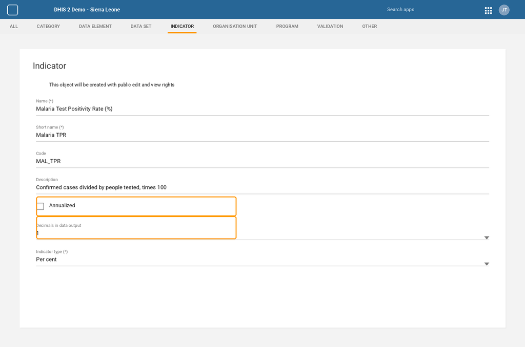

123

**Figure 11.** Annualized off and one decimal, the two fields that change the output. *This picture was drawn for the guide, using the indicator we are building. Your screen will show your own names and dates.*

1. 1**Annualized.** Off. On would scale a monthly value to a year, which this rate must not be.
2. 2**Decimals.** 1, so the dashboard shows 68.2 rather than 68.
3. 3**The name.** Keep the per cent sign in the name, so the decimals make sense to readers.

Step 12: Review the Complete Indicator Formula

Before saving, review the complete calculation.

```
Malaria Testing Rate (%)

                    Malaria Tests Performed
                    ──────────────────────── × 100
                    Malaria Suspected Cases
```

**Example:**  
Tests performed = 220  
Suspected cases = 250  
Indicator = (220 ÷ 250) × 100 = 88%

**Expected result:** The formula produces a meaningful value between 0 and 100% when the denominator is positive.

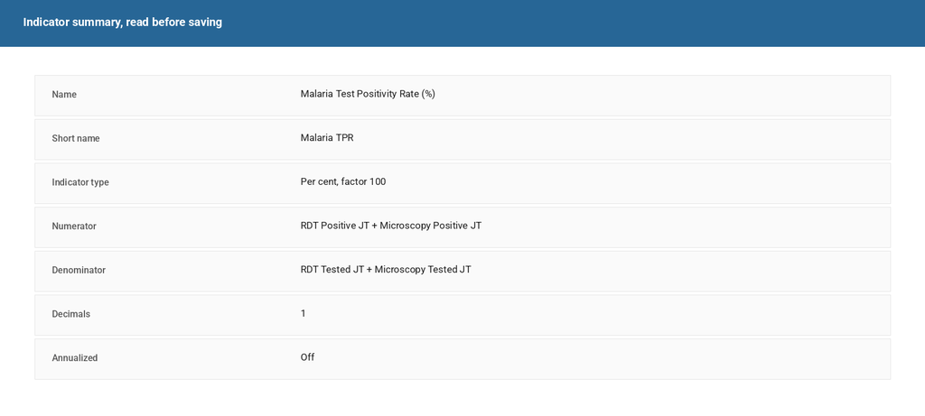

12345

**Figure 12.** The whole indicator on one page, to read before saving. *This picture was drawn for the guide, using the indicator we are building. Your screen will show your own names and dates.*

1. 1**Name.** What people will search for.
2. 2**Indicator type.** Per cent, factor 100.
3. 3**Numerator.** Both positive results added together.
4. 4**Denominator.** Both test methods added together.
5. 5**Annualized.** Off. Read the whole panel out loud before clicking save.

Step 13: Save the Indicator

Review the name, type, numerator, denominator, factor and aggregation settings.

**Click:** Save / Create

**Expected result:** The indicator appears in the Indicators list.

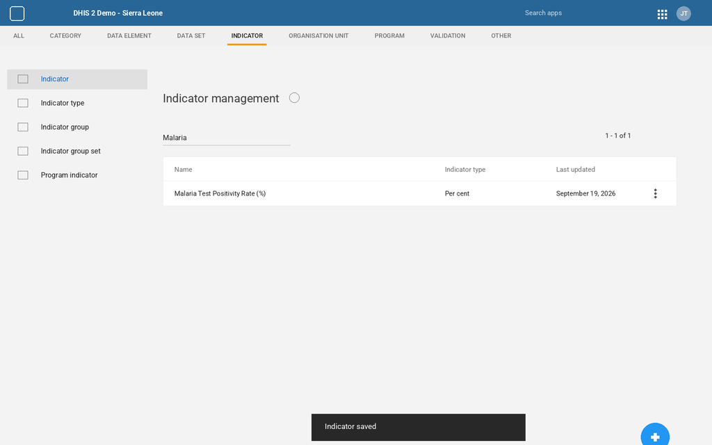

123456

**Figure 13.** The saved indicator in the list, with the confirmation message. *This picture was drawn for the guide, using the indicator we are building. Your screen will show your own names and dates.*

1. 1**Search.** Malaria, to find what you just made.
2. 2**Count.** 1 to 1 of 1, so only your new indicator matches.
3. 3**The indicator.** Malaria Test Positivity Rate (%).
4. 4**Indicator type.** Per cent, exactly as you set it.
5. 5**The message.** Indicator saved. If it does not appear, something was rejected.
6. 6**Blue plus.** Use it again for the next indicator in Step 18.

Step 14: Configure Indicator Sharing

Make sure the appropriate users and user groups can access the indicator.

**Open:** Indicator → Sharing / Access

Configure access according to your implementation's governance requirements.

**Expected result:** Intended users can use the indicator in analytics applications where they have the required permissions.

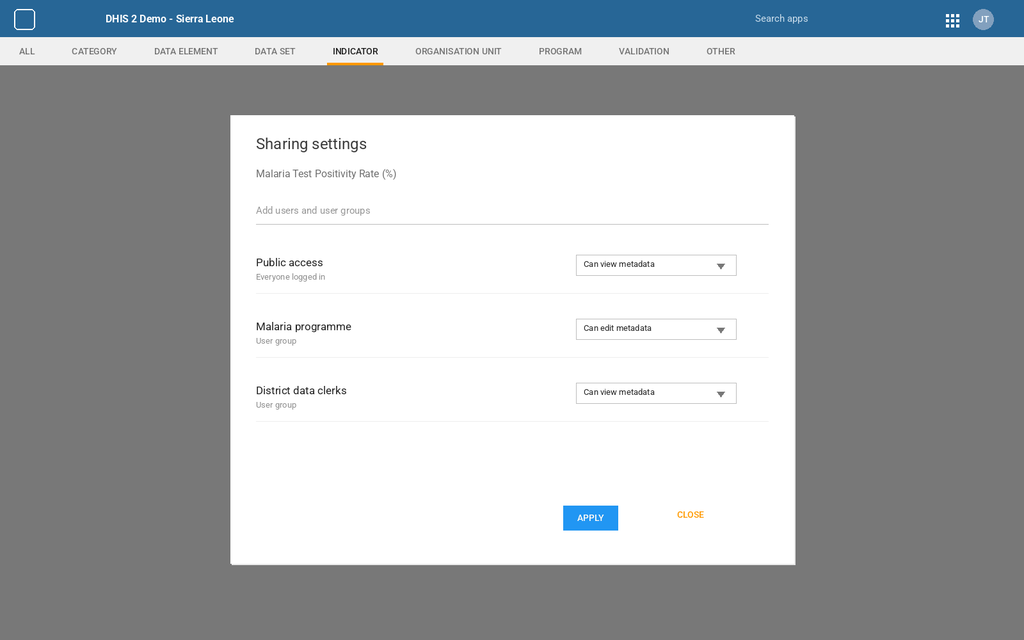

123456

**Figure 14.** Sharing settings for the indicator. *This picture was drawn for the guide, using the indicator we are building. Your screen will show your own names and dates.*

1. 1**Sharing settings.** Opened from the row menu of the indicator.
2. 2**Add users and user groups.** Type a group name to give it access.
3. 3**Public access.** Everyone logged in. Leave view access unless there is a reason not to.
4. 4**What they can do.** Metadata access decides who can change the formula.
5. 5**User groups.** The programme team and the district clerks, each with their own level.
6. 6**APPLY.** Saves the sharing settings.

Step 15: Test the Indicator in Data Visualizer

Open Data Visualizer and search for the indicator.

**Click:** Apps → Data Visualizer → Select the indicator

Select an organisation unit and reporting period with known underlying data.

**Expected result:** The indicator returns a calculated value rather than displaying an unexpected blank or error.

[figure not shown]

123456

**Figure 15.** The indicator in the Data Visualizer, returning a number. *This picture was drawn for the guide, using the indicator we are building. Your screen will show your own names and dates.*

1. 1**Data.** Choose Indicators, then your indicator.
2. 2**Columns.** Data, so the indicator runs across the top.
3. 3**Rows.** Period, so the months run down the side.
4. 4**Filter.** One organisation unit, here the country.
5. 5**The column heading.** Malaria Test Positivity Rate (%).
6. 6**The values.** Numbers, not blanks. A blank here means no data in that month.

Step 16: Compare the DHIS2 Result With a Manual Calculation

Always manually calculate at least one test value.

**Example:**  
Malaria Tests Performed = 220  
Malaria Suspected Cases = 250  
Manual calculation:  
220 ÷ 250 × 100 = 88%

Compare the manual result with the value returned by DHIS2.

**Expected result:** The DHIS2 result agrees with the manually calculated value, subject to the configured aggregation and data dimensions.

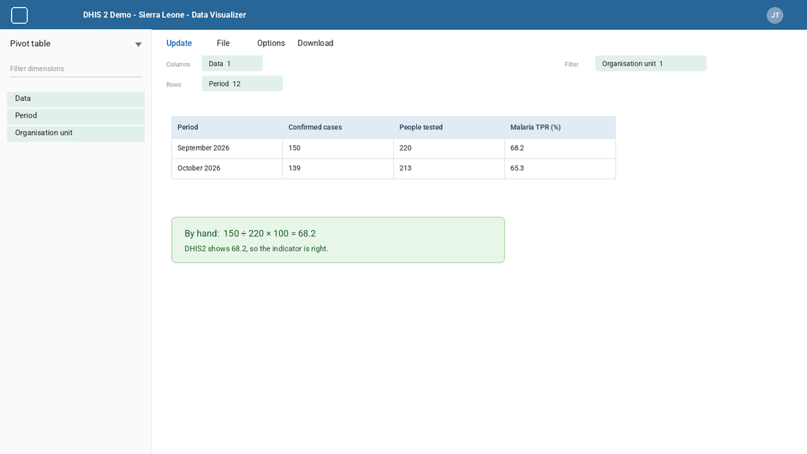

12345

**Figure 16.** The numerator, the denominator and the indicator side by side. *This picture was drawn for the guide, using the indicator we are building. Your screen will show your own names and dates.*

1. 1**Confirmed cases.** The numerator, added from the raw data elements.
2. 2**People tested.** The denominator.
3. 3**The indicator.** What DHIS2 worked out.
4. 4**One row.** Take one month and read all three numbers across.
5. 5**The check.** 150 ÷ 220 × 100 = 68.2, which matches. If yours is 0.68, the factor is wrong.

Step 17: Test Zero and Missing Denominators

Test what happens when the denominator is zero or missing.

Denominator = 0  
Numerator = 0

Review the behavior in your DHIS2 version. A percentage cannot be meaningfully calculated when its denominator is zero.

**Action:** Confirm that your reporting and analytical interpretation handles zero/missing denominators correctly.

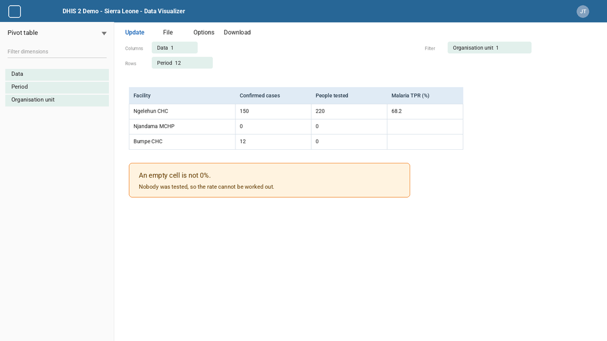

12345

**Figure 17.** Facilities with no tests: the cell is empty, not zero. *This picture was drawn for the guide, using the indicator we are building. Your screen will show your own names and dates.*

1. 1**A facility with data.** Cases, tests and a rate, all present.
2. 2**A facility with zeros.** Nobody was tested, so there is nothing to divide by.
3. 3**The empty cell.** DHIS2 leaves it blank rather than showing 0%.
4. 4**Cases without tests.** Twelve confirmed but nobody tested means the data is wrong, not the indicator.
5. 5**What to say.** An empty cell is a missing denominator, and should be reported as such.

Step 18: Create Additional Malaria Indicators

Once the first indicator works, use the same process to create the remaining programme indicators.

| Indicator | Numerator | Denominator | Factor |
| --- | --- | --- | --- |
| Malaria Testing Rate (%) | Malaria tests performed | Suspected malaria cases | 100 |
| Test Positivity Rate (%) | Confirmed malaria cases | Malaria tests performed | 100 |
| ACT Treatment Rate (%) | Patients treated with ACT | Confirmed uncomplicated cases | 100 |
| Referral Rate (%) | Malaria referrals | Malaria cases | 100 |

**Important:** Confirm the programme's official indicator definitions before implementing these formulas. The examples above illustrate the structure, not a replacement for the NMCP indicator reference definitions.

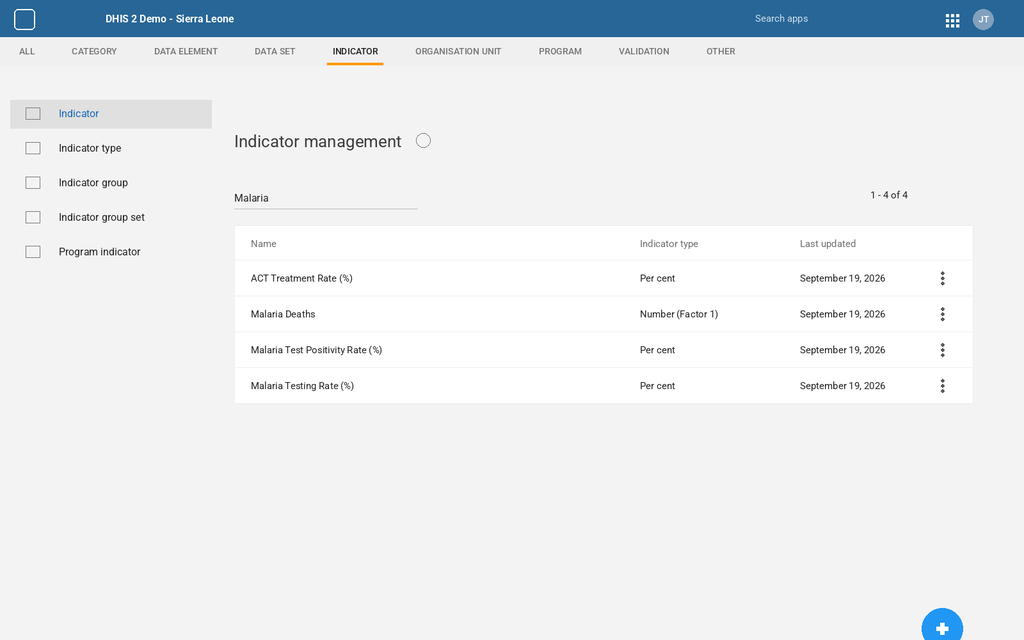

123456

1. 1**Search.** Malaria.
2. 2**Count.** 1 to 4 of 4.
3. 3**ACT Treatment Rate (%).** Treated with ACT over confirmed cases.
4. 4**Malaria Deaths.** A plain count, with a denominator of 1.
5. 5**Test Positivity Rate (%).** The one built in this guide.
6. 6**Indicator type.** Number (Factor 1) for the count, Per cent for the rates.

Step 19: Final Indicator Quality Check

- ☐ Indicator name is clear.
- ☐ Short name is appropriate.
- ☐ Code is unique if codes are used.
- ☐ Indicator type is correct.
- ☐ Numerator is correct.
- ☐ Denominator is correct.
- ☐ Factor is correct.
- ☐ Aggregation operators are appropriate.
- ☐ Sharing/access is configured.
- ☐ Indicator has been tested with known data.
- ☐ Manual calculation agrees with DHIS2.
- ☐ Zero/missing denominator behavior has been reviewed.
- ☐ Indicator works in Data Visualizer.
- ☐ Programme definition has been checked against the official indicator reference.

**Final result:** The indicator is configured, tested and ready for approved analytical use.

[figure not shown]

12345

**Figure 19.** The details panel, used for the final check. *This picture was drawn for the guide, using the indicator we are building. Your screen will show your own names and dates.*

1. 1**Name.** Reads correctly, with the unit.
2. 2**Indicator type.** Per cent.
3. 3**Numerator.** Both positives.
4. 4**Denominator.** Both test methods.
5. 5**Annualized and decimals.** Off and 1. Tick every line of the checklist against this panel.

**Important distinction:** An indicator is a calculated analytical object. It is not normally a replacement for the underlying data elements. Keep the underlying data elements well defined and use indicators to calculate the programme measures derived from them.

DHIS2 Indicators — Step-by-Step Implementation Guide